# Measures of Location: Second Moment

[John S Butler (TU Dublin)](https://johnsbutler.netlify.com)

# Second Moment

## Variance

### Definition:

The variance $Var(x),$ $\sigma^2$ is the spread of the data around the mean $\bar{x}$. The formula is given by
$$\sigma^2=\frac{\sum_{i=1}^n (x_i-\bar{x})^2}{n-1},$$
where $x_i$ is each element, $\bar{x}$ is the average of the elements and $n$ is the number of elements.

### Example

[output not shown]

$$\frac{\sum_{i=1}^7 (x_i-\bar{x})^2}{7-1}=\frac{1.65306122+ 0.51020408 +0.08163265 +0.51020408 +0.51020408 +0.51020408+ 1.65306122}{7-1}=0.9047619.$$
Or you could just use the command Var().

In R code:

```r
Age=c(20, 18,19, 18,18,18,20) # List of 7 numbers
## Cacluate the variance in the long form
Age-mean(Age) # Each element minus the mean
```

```
## [1]  1.2857143 -0.7142857  0.2857143 -0.7142857 -0.7142857 -0.7142857
## [7]  1.2857143
```

```r
(Age-mean(Age))^2# Each element minus the mean
```

```
## [1] 1.65306122 0.51020408 0.08163265 0.51020408 0.51020408 0.51020408
## [7] 1.65306122
```

```r
sum((Age-mean(Age))^2)/6 #Sum the elements and divide by (7-1)=6
```

```
## [1] 0.9047619
```

```r
# Or just use the function
var(Age)
```

```
## [1] 0.9047619
```

## Standard Deviation

### Definition:

The standard deviation is the square root of the variance.

$$\sigma=\sqrt{\frac{\sum_{i=1}^n (x_i-\bar{x})^2}{n-1}},$$
where $x_i$ is each element, $\bar{x}$ is the average of the elements and $n$ is the number of elements. In R-code

```r
Age=c(20, 18,19, 18,18,18,20) # List of 7 numbers
sd(Age) # Each element minus the mean
```

```
## [1] 0.9511897
```

### Standard Deviation and Variance Pros and Cons

Pros of the standard deviation and variance:

- Takes all data into account.
- Lends itself to computation of other stable measures (and is a prerequisite for many of them).

Cons of the mean: * Hard to interpret. * Can be influenced by extreme scores.

### Graphical representation of the variance/standard deviation:

The figure below shows the histogram from 2000 Age observations at a concert:

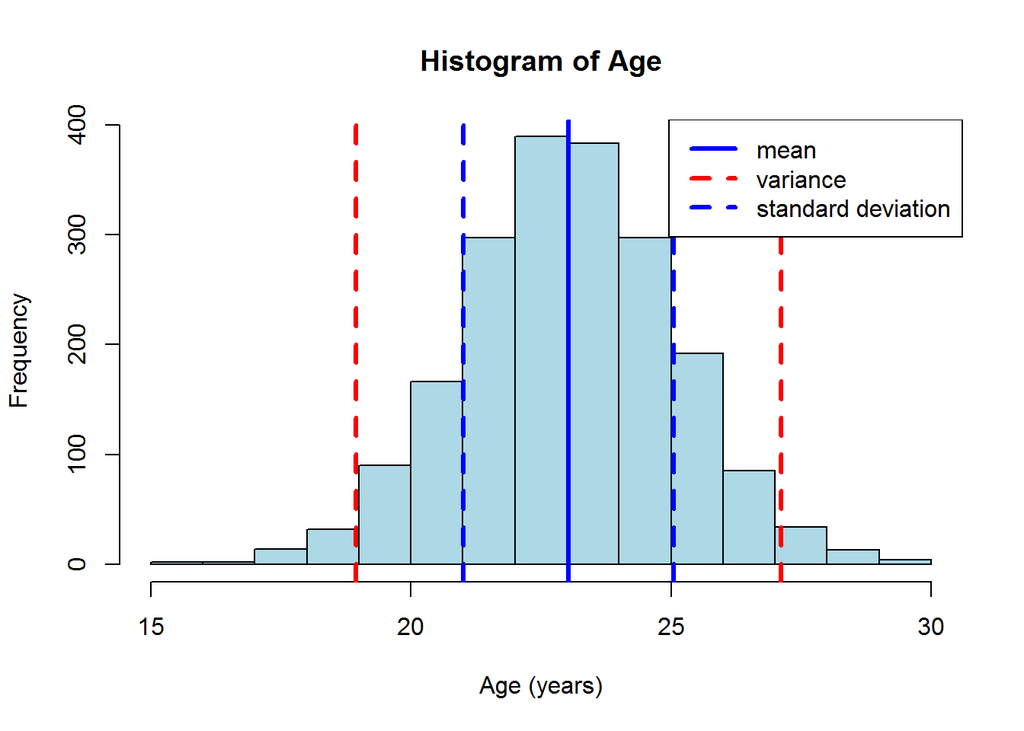

```r
Age<-rnorm(2000,23,2)
hist(Age,col="lightblue",xlab="Age (years)",xlim=c(15,30)) # Histogram of the 7 numbers
abline(v=mean(Age),col="blue",lwd=3)# line indicating the mean
abline(v=c(mean(Age)-var(Age),mean(Age)+var(Age)), col=c("red", "red"), lty=c(2,2), lwd=c(3, 3))
abline(v=c(mean(Age)-sd(Age),mean(Age)+sd(Age)), col=c("blue", "blue"), lty=c(2,2), lwd=c(3, 3))
legend("topright",c("mean","variance","standard deviation"),lwd=c(3,3,3),lty=c(1,2,2),col=c("blue","red","blue"))
```